# skanaba1_finalexam

Sonal Kanabar

#### Project Information

*CRISA is an Asian market research agency that specializes in tracking consumer purchase behavior in consumer goods (both durable and nondurable).

*To track purchase behavior,a subset of 600 records is analyzed here.

*CRISA now like to segment the market based on two key sets of variables more directly related to the purchase process and to brand loyalty

#### Libraries Used

```r
library(dplyr)      #for conversion of %columns to numeric variables for calculations
library(factoextra) #for clustering algorithms & visualization
library(ggplot2)    #visualization
library(GGally)     #graph
library(mcclust)    #modeling clusters
```

#### Importing dataset in R

```r
mydata <- read.csv("BathSoap.csv") #600 observations, 46 variables

#Howering the dataset
#sum(is.na(mydata)) #there are no missing values in the dataset
#View(mydata)
#colnames(mydata)
#str(mydata)
#summary(mydata)
```

#### Data Transformation

```r
#Duplicating the dataset and then using it further for transformation and analysis
BathSoap_data <- mydata

#Converting the % data to decimal form
BathSoap_data[ ,20:46] <- apply(BathSoap_data[ ,20:46],2,function(x) {as.numeric(sub("%", "", x,fixed=TRUE))/100})

#Converting variables to factors
BathSoap_data[,c(1:10,12)] <- lapply(BathSoap_data[,c(1:10,12)], factor)

#Giving row number as the name of " Member Id "  and then eliminating the variable name from the dataset to avoid redundency
rownames(BathSoap_data) <- BathSoap_data$Member.id
BathSoap_data$Member.id = NULL

#summary(BathSoap_data)
#head(BathSoap_data)
```

### 1. Kmeans Clustering to identify clusters of households based on:

##### A. Purchase Behavior (including brand loyalty)

*I. Variables that describes purchase behavior: Brand Runs, Total Volume, No. of Trans, Value, Trans/ Brand Runs, Vol/Trans, Avg. Price,Pur Vol

*II. Brand Loyalty: Br.Cd.(57,144),55,272,286,24,481,352,5,and 999(others)

```r
PurBehvr_Data <- BathSoap_data[,c("Brand.Runs","Total.Volume", "No..of..Trans","Value","Trans...Brand.Runs","Vol.Tran","Avg..Price", "Pur.Vol.No.Promo....","Br..Cd..57..144","Br..Cd..55","Br..Cd..272","Br..Cd..286", "Br..Cd..24","Br..Cd..481","Br..Cd..352","Br..Cd..5", "Others.999")]
#View(PurBehvr_Data)

#Normalizing the dataset
PurBehvr_Data <- as.data.frame(scale(PurBehvr_Data))
#summary(PurBehvr_Data)
#head(PurBehvr_Data)
```

##### Determining K value

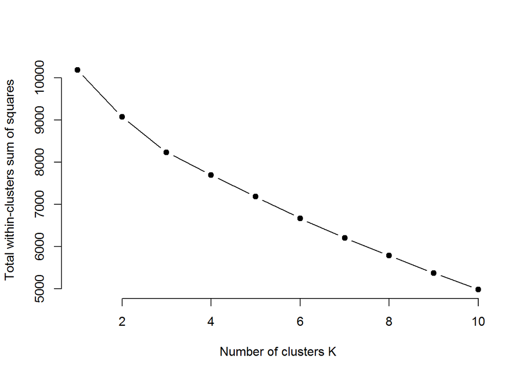

```r
#Elbow Method for finding the optimal number of clusters
set.seed(2019)
# Compute and plot wss for k = 2 to k = 10.
k.max <- 10
data <- PurBehvr_Data
wss <- sapply(1:k.max,
              function(k){kmeans(data, k, nstart=25,iter.max = 15 )$tot.withinss})
wss
plot(1:k.max, wss,
     type="b", pch = 19, frame = FALSE,
     xlab="Number of clusters K",
     ylab="Total within-clusters sum of squares")
```

*Therefore for k=3 the between_ss/total_ss ratio tends to change slowly and remain less changing as compared to other k’s.so for this data k=3 should be a good choice for number of clusters

```r
set.seed(2019)
#k-means
km1 <- kmeans(PurBehvr_Data, centers = 3, nstart = 25)
#km1$centers   #centers of clusters
#km1$size      #size of each clusters

#Store the cluster assigned to the dataset
PurBehvr_Data <- as.data.frame(cbind(km1$cluster, PurBehvr_Data))
colnames(PurBehvr_Data)[1] <- "cluster"

#Converting the cluster to a factor
PurBehvr_Data$cluster <- as.factor(PurBehvr_Data$cluster)
#summary(PurBehvr_Data)
```

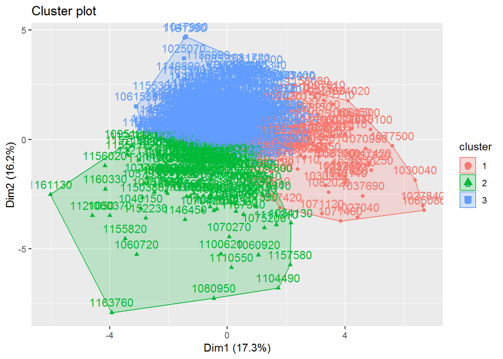

```r
# Plot
fviz_cluster(km1, data = PurBehvr_Data[ , -c(1)])
```

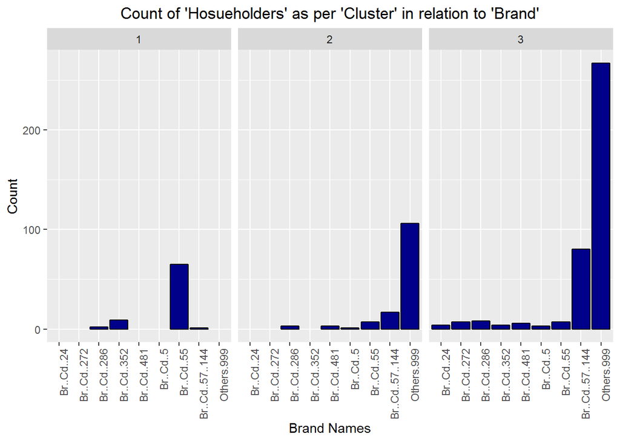

```r
#Creating a dataset "DF" and storing the propotion values of Brand names, so that we can create a new column "High_Brand_Value_Name" which will find the highest value of all the rows and will print the name of the column which it belongs to in the new variable.
DF <- data.frame(BathSoap_data[,c(22:30)])
PurBehvr_Data$High_Brand_Value_Name <- colnames(DF)[apply(DF,1,which.max)]

# Ploting graph by Brand Name
ggplot(data = PurBehvr_Data) +
  geom_bar(mapping = aes(PurBehvr_Data$High_Brand_Value_Name),
           col = "black",
           fill = "blue4") +
  facet_wrap(vars(PurBehvr_Data$cluster)) +
  labs(title = "Count of 'Hosueholders' as per 'Cluster' in relation to 'Brand'") +
  labs(x = "Brand Names", y = "Count") +
  theme(axis.text.x = element_text(angle = 90, hjust = 1),plot.title = element_text(hjust = 0.5))
```

#### B. Basis of Purchase

*Variables used: Pur Vol No Promo-%, Vol Promo 6%, Pur Vol Other Promo %, Price Cat 1 to 4, Proposition Cat 5 to 15

```r
Purchase_Base_data <- BathSoap_data[,c("Pur.Vol.No.Promo....","Pur.Vol.Promo.6..", "Pur.Vol.Other.Promo..","Pr.Cat.1" ,"Pr.Cat.2","Pr.Cat.3","Pr.Cat.4", "PropCat.5","PropCat.6" ,"PropCat.7","PropCat.8","PropCat.9","PropCat.10","PropCat.11","PropCat.12","PropCat.13","PropCat.14","PropCat.15"
)]
#Data Normalization
Purchase_Base_data <- as.data.frame(scale(Purchase_Base_data))
#head(Purchase_Base_data)
#summary(Purchase_Base_data)
```

##### Determining the value of K

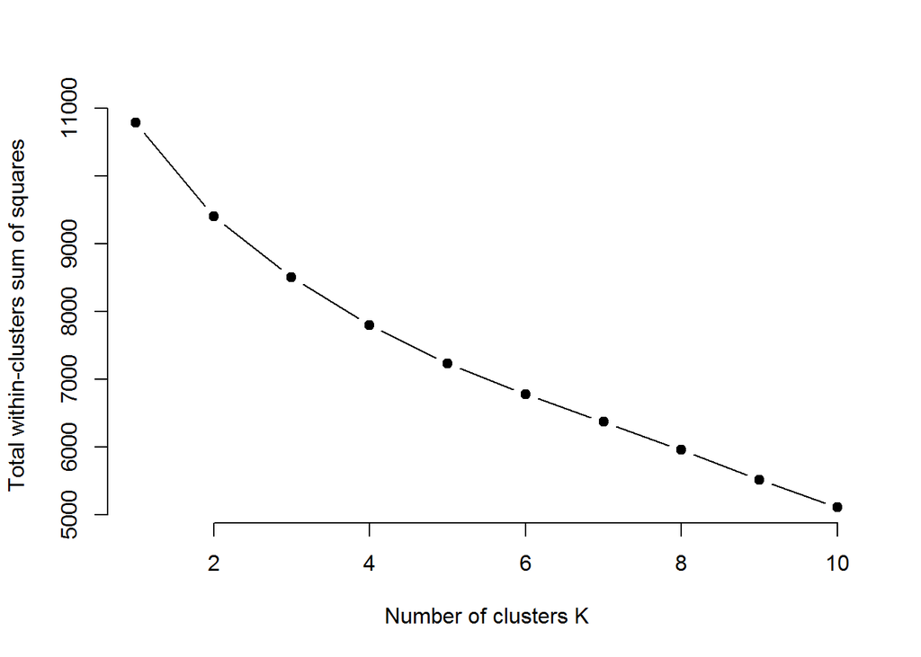

```r
#Elbow Method for finding the optimal number of clusters
set.seed(2019)
# Compute and plot wss for k = 2 to k = 10.
k.max <- 10
data2 <- Purchase_Base_data
wss <- sapply(1:k.max,
              function(k){kmeans(data2, k, nstart=25,iter.max = 15 )$tot.withinss})
wss
plot(1:k.max, wss,
     type="b", pch = 19, frame = FALSE,
     xlab="Number of clusters K",
     ylab="Total within-clusters sum of squares")
```

*Therefore for k=3 the between_ss/total_ss ratio tends to change slowly and remain less changing as compared to other k’s.so for this data k=3 should be a good choice for number of clusters

```r
set.seed(2019)

#k-means
km2 <- kmeans(Purchase_Base_data, centers = 3, nstart = 25)
#size of each cluster
km2$size

#Store the cluster assigned to the dataset
Purchase_Base_data <- as.data.frame(cbind(km2$cluster, Purchase_Base_data))
colnames(Purchase_Base_data)[1] <- "cluster"

#Converting the cluster to a factor
Purchase_Base_data$cluster <- as.factor(Purchase_Base_data$cluster)
#summary(Purchase_Base_data)
```

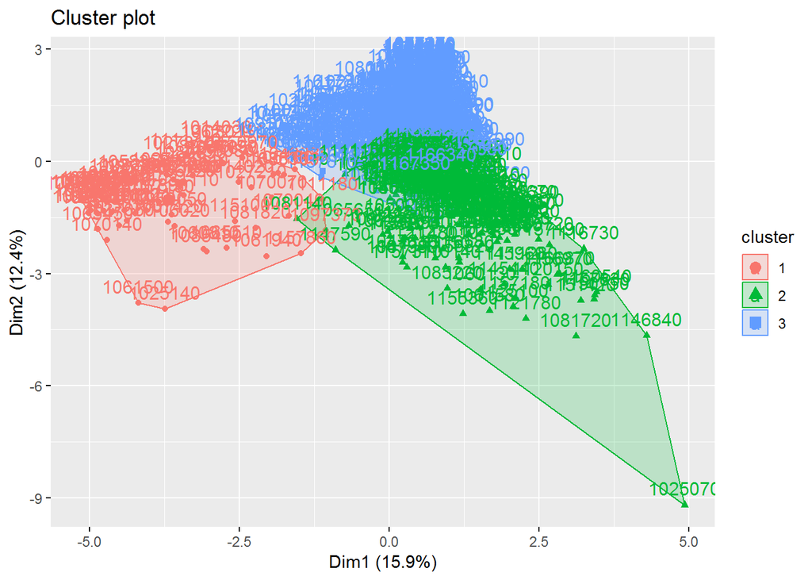

```r
# Plots of the variables
fviz_cluster(km2, data = Purchase_Base_data[ , -c(1)])
```

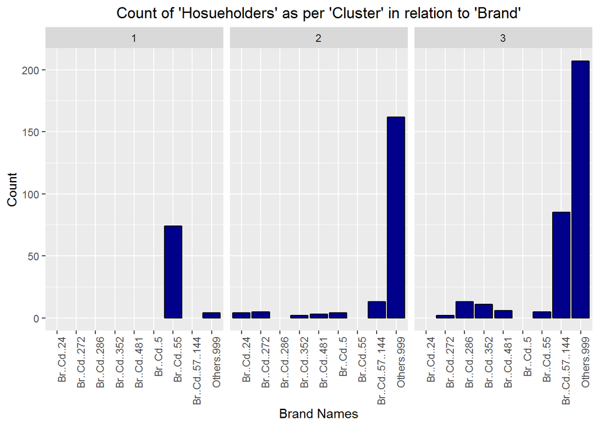

```r
# Plot by Brand Name
ggplot(data = Purchase_Base_data) +
  geom_bar(mapping = aes(PurBehvr_Data$High_Brand_Value_Name),
           col = "black",
           fill = "blue4") +
  facet_wrap(vars(Purchase_Base_data$cluster)) +
  labs(title = "Count of 'Hosueholders' as per 'Cluster' in relation to 'Brand'") +
  labs(x = "Brand Names", y = "Count") +
  theme(axis.text.x = element_text(angle = 90, hjust = 1),plot.title = element_text(hjust = 0.5))
```

#### c. Purchase Behaviour & Basis of Purchase

*I. Variables that describes “Purchase behavior”: Brand Runs, Total Volume, No. of Trans, Value, Trans/ Brand Runs, Vol/Trans, Avg. Price,Pur Vol,Br.Cd.(57,144),55,272,286,24,481,352,5,and 999(others)

*II. Variables that describe “Basis of”Purchase“: Pur Vol No Promo-%, Vol Promo 6%, Pur Vol Other Promo %, Price Cat 1 to 4, Proposition Cat 5 to 15

```r
Behaviour_n_Basis<- BathSoap_data[,c("Brand.Runs","Total.Volume", "No..of..Trans","Value","Trans...Brand.Runs","Vol.Tran","Avg..Price", "Pur.Vol.No.Promo....", "Br..Cd..57..144","Br..Cd..55","Br..Cd..272","Br..Cd..286", "Br..Cd..24","Br..Cd..481", "Br..Cd..352","Br..Cd..5","Others.999","Pur.Vol.No.Promo....","Pur.Vol.Promo.6..", "Pur.Vol.Other.Promo..","Pr.Cat.1" ,"Pr.Cat.2","Pr.Cat.3","Pr.Cat.4", "PropCat.5","PropCat.6" ,"PropCat.7","PropCat.8","PropCat.9","PropCat.10","PropCat.11","PropCat.12","PropCat.13","PropCat.14","PropCat.15")]

#Normalizing the dataset
Behaviour_n_Basis <- as.data.frame(scale(Behaviour_n_Basis))
#head(Behaviour_n_Basis)
```

##### Determining the value of K

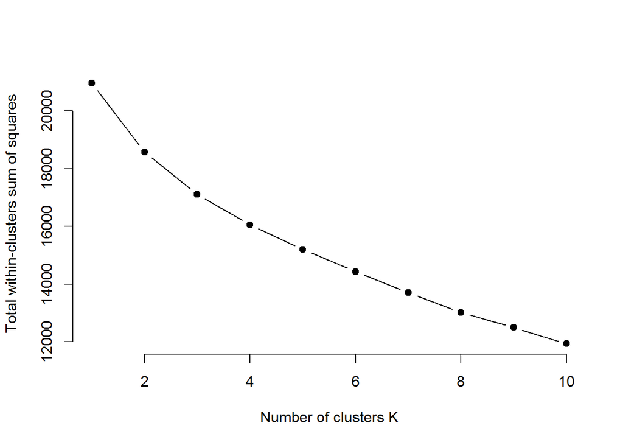

```r
#Elbow Method for finding the optimal number of clusters
set.seed(2019)
# Compute and plot wss for k = 2 to k = 10.
k.max <- 10
data3 <- Behaviour_n_Basis
wss <- sapply(1:k.max,
              function(k){kmeans(data3, k, nstart=25,iter.max = 15 )$tot.withinss})
wss
plot(1:k.max, wss,
     type="b", pch = 19, frame = FALSE,
     xlab="Number of clusters K",
     ylab="Total within-clusters sum of squares")
```

*Therefore for k=3 the between_ss/total_ss ratio tends to change slowly and remain less changing as compared to other k’s.so for this data k=3 should be a good choice for number of clusters

```r
set.seed(2019)

#k-means
km3 <- kmeans(Behaviour_n_Basis, centers = 3, nstart = 25)

#size of each cluster
km3$size

#Store the cluster assigned to the dataset
Behaviour_n_Basis <- as.data.frame(cbind(km3$cluster, Behaviour_n_Basis))
colnames(Behaviour_n_Basis)[1] <- "cluster"

#Converting the cluster to a factor
Behaviour_n_Basis$cluster <- as.factor(Behaviour_n_Basis$cluster)
#summary(Behaviour_n_Basis)
```

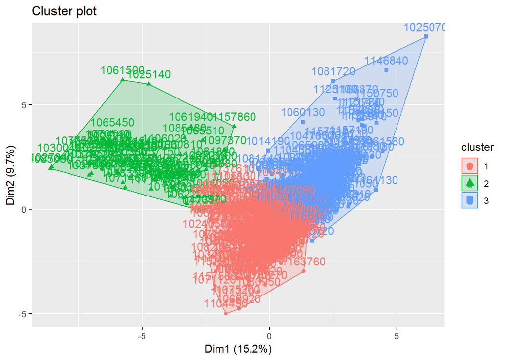

```r
# Ploting variables
fviz_cluster(km3, data = Behaviour_n_Basis[ , -c(1)])
```

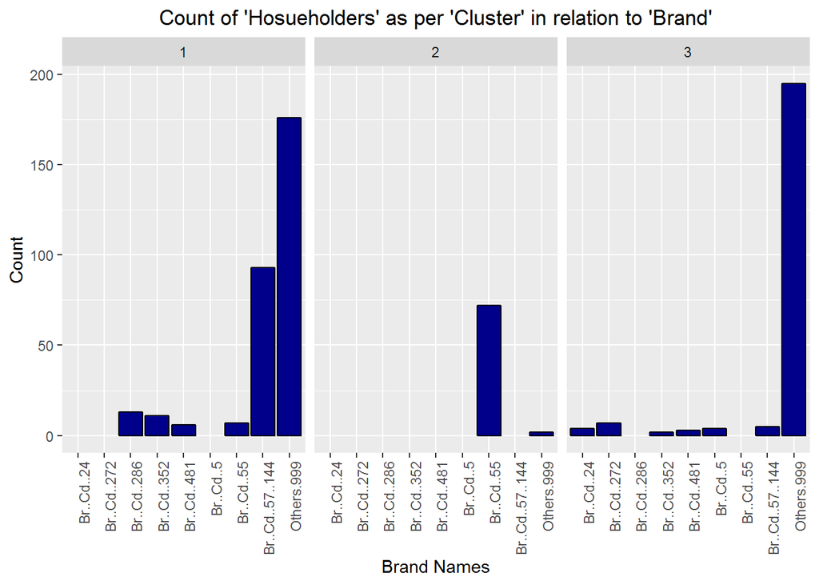

```r
# Ploting graph by Brand Name
ggplot(data = Behaviour_n_Basis) +
  geom_bar(mapping = aes(PurBehvr_Data$High_Brand_Value_Name),
           col = "black",
           fill = "blue4") +
  facet_wrap(vars(Behaviour_n_Basis$cluster)) +
  labs(title = "Count of 'Hosueholders' as per 'Cluster' in relation to 'Brand'") +
  labs(x = "Brand Names", y = "Count") +
  theme(axis.text.x = element_text(angle = 90, hjust = 1),plot.title = element_text(hjust = 0.5))
```

### 2. Market Segmentation

*As per the analysis of characteristics (demographic, brand loyalty and basis of purchase) the best segmentation is the third one where we consider both the aspects i.e purchase behaviour (brand loyalty) and basis of purchase.

*To get the result/s of the other variable/s we need to replace the CS variable name to the respective variable we want to do visualization on.

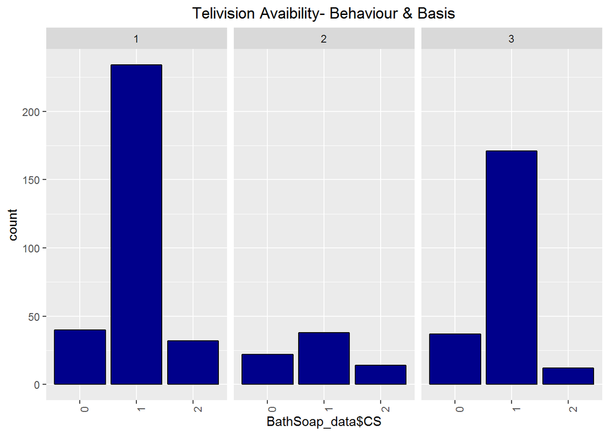

```r
#Analysis:

#Ploting graph by "CS":- Telivision Avaibiity

#Behaviour & Basis Data
ggplot(data = Behaviour_n_Basis) +
  geom_bar(mapping = aes(BathSoap_data$CS),
           col = "black",
           fill = "blue4") +
  facet_wrap(vars(Behaviour_n_Basis$cluster)) +
  labs(title = "Telivision Avaibility- Behaviour & Basis") +
theme(axis.text.x = element_text(angle = 90, hjust = 1), plot.title = element_text(hjust = 0.5))
```

```r
##Insights on Demographics:
Demogr_data = cbind(mydata, Cluster =Behaviour_n_Basis$cluster)
agg_data = aggregate(cbind(SEC, FEH, MT, SEX, AGE, EDU, HS, CHILD, CS,
Affluence.Index) ~ Cluster, data = Demogr_data, mean, na.rm = FALSE)
#agg_data
```

Analysis:

1. As per the observation/visuals from the chart we can figure that “Others 999” brand name are hight in Cluster 1 and Cluster 3.
2. More detailed data collection should be done , which will help understand if the “Other 999” brand has any hidden pattern in it. If it has more customer within same brand than the others.
3. Cluster 1 and Cluster 3 have highest counts of householders who have telivision with them. This may be one of triggerd reasons why there are more householders in the same clusters have high product of “Other 999” brand. They must have seen advertisement in the telivision which may have encouraged them to try new product than the usual.And hence cluster 1 and Cluster 3 have high count of “other 999” brand.
4. The ‘CS’ variable, i.e Telivision avaibility has ‘zero’ in it. Which means many householders have not answered the survey. Because of it there may be a possibility me might miss out of important information. So specific questions which are related to variables should be made mandatory to be answered.
5. Highest level of Socio Economic class belongs in Cluster 2 and it has high brand loyalty on “Br..Cd..55” .There is a possibility that the product is expensive and defines as a status symbol in the society.
6. Cluster 2 has the highest count of family and majority of the data is towards “Br..Cd..55”, there might be a possibility that the product must be specific to kids(Baby product) and that’s why the householders in that cluster are buying that specific product only.
7. Affluenece Index is lowest in cluster 2 , maybe because of the householders have kids in the family and their earnings would be used on tutions, health, insurance, education, etc and therefore they must not have much of wealth/savings.

### 3. Classification Model

*I. Method: k means clustering for classification model

*II. Variables used:“Pur.Vol.No.Promo….”,“Pur.Vol.Promo.6..”,“Pur.Vol.Other.Promo..”

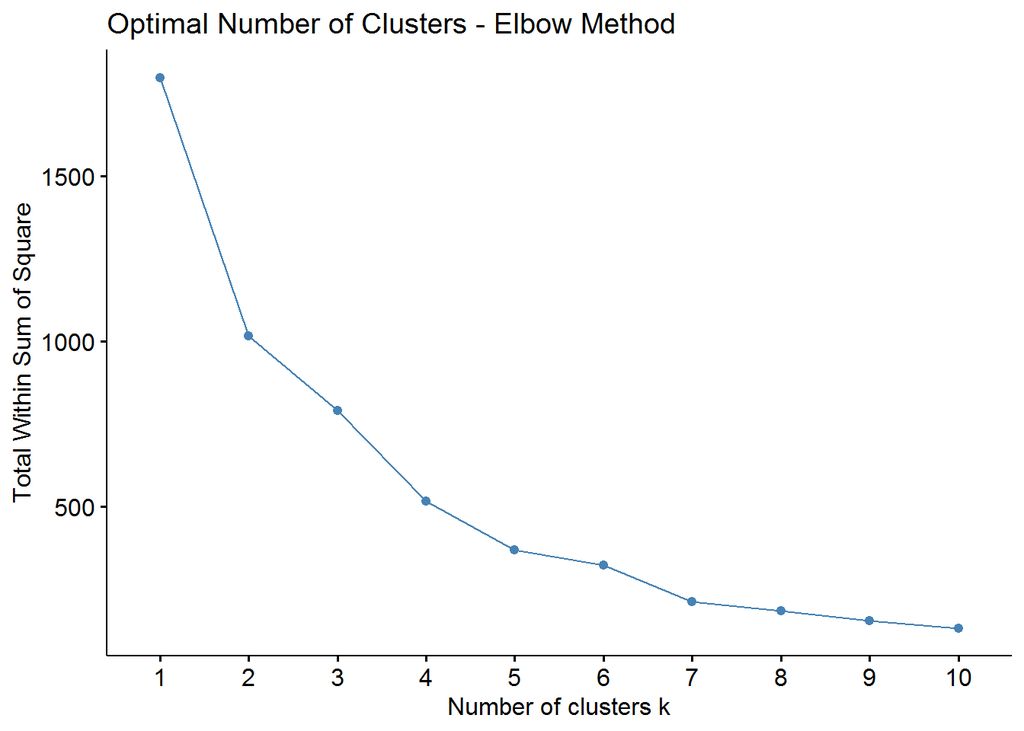

```r
#Building model based on 3 variables.
ClassM<-BathSoap_data[,c(19:21)]
Class_M_Scaled<-as.data.frame(scale(ClassM))

set.seed(2019)
fviz_nbclust(Class_M_Scaled, kmeans, method = "wss") +
  labs(title = "Optimal Number of Clusters - Elbow Method")
```

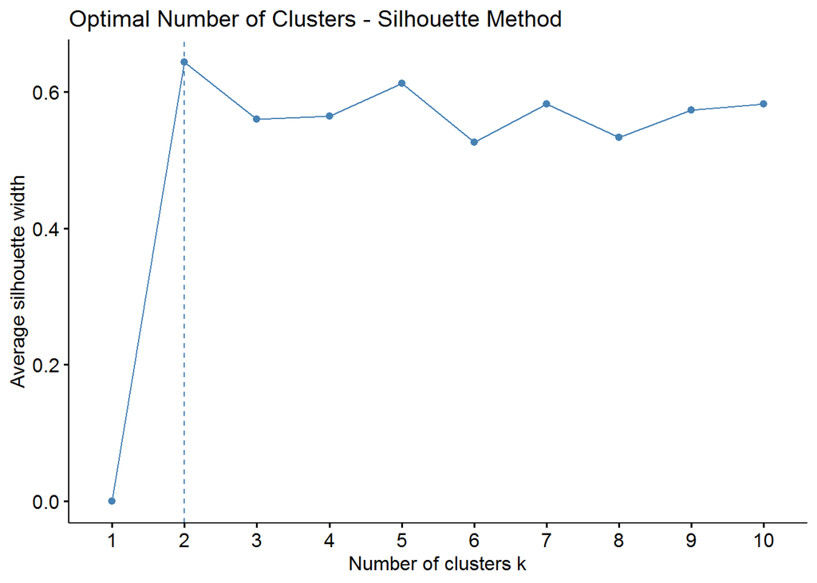

```r
fviz_nbclust(Class_M_Scaled, kmeans, method = "silhouette") +
  labs(title = "Optimal Number of Clusters - Silhouette Method")
```

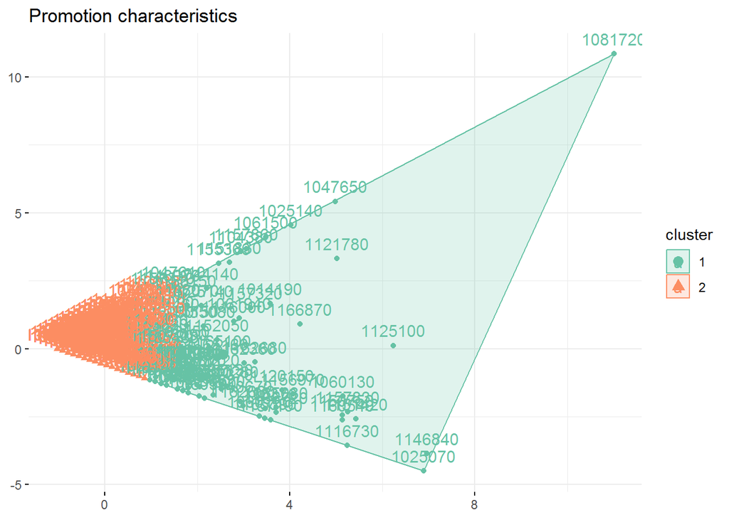

```r
#K-means for classification model
set.seed(2019)
cls <- kmeans(Class_M_Scaled, centers =2 , nstart = 100) #k=2

#plotting k-means model
fviz_cluster(cls, data = Class_M_Scaled, main="Promotion characteristics",
             xlab = FALSE,ylab = FALSE,palette = "Set2", ggtheme = theme_minimal())
```

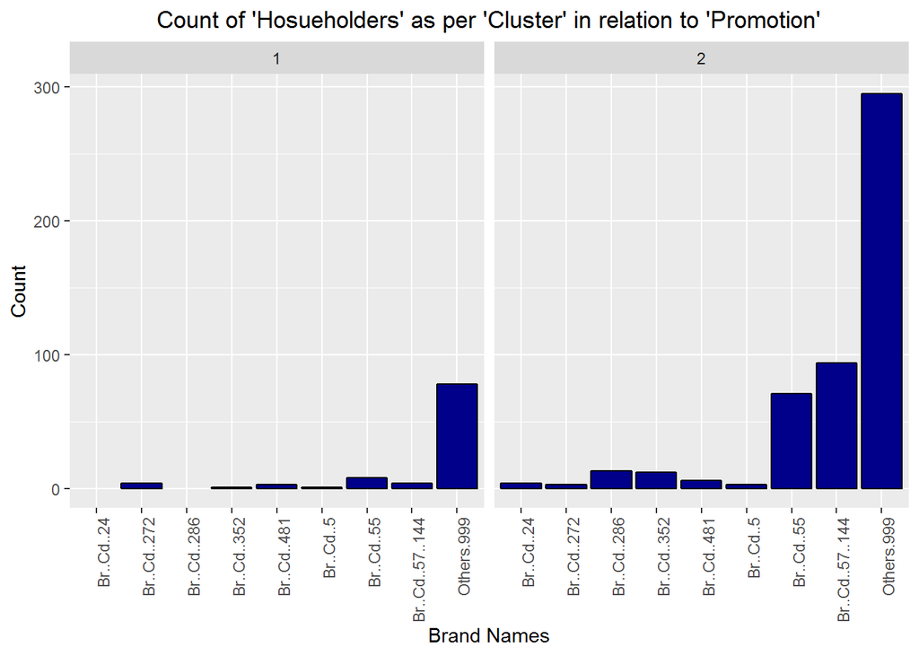

```r
#Store the cluster assigned to the dataset
Class_M_Scaled <- as.data.frame(cbind(cls$cluster, Class_M_Scaled))
colnames(Class_M_Scaled)[1] <- "cluster"

#Converting the cluster to a factor
Class_M_Scaled$cluster <- as.factor(Class_M_Scaled$cluster)

# Plot on basis of Promotion
ggplot(data = Class_M_Scaled) +
  geom_bar(mapping = aes(PurBehvr_Data$High_Brand_Value_Name),
           col = "black",
           fill = "blue4") +
  facet_wrap(vars(Class_M_Scaled$cluster)) +
  labs(title = "Count of 'Hosueholders' as per 'Cluster' in relation to 'Promotion'") +
  labs(x = "Brand Names", y = "Count") +
  theme(axis.text.x = element_text(angle = 90, hjust = 1),plot.title = element_text(hjust = 0.5))
```

*Conclusions:

Cluster 2 have householders which are Brand Loyal. So if we have promotions/offers than cluster 1 householders should be our target audience as they are price sensitive and could be a potential customer.